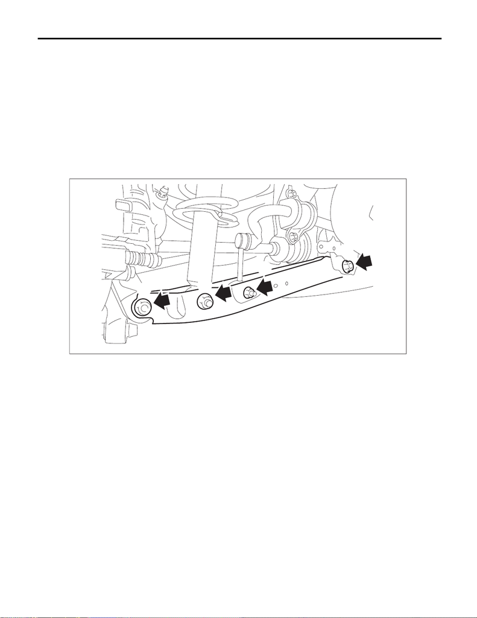

Rear Lateral Link

REAR SUSPENSION

8. Rear Lateral Link

A: REMOVAL

1) Disconnect the ground cable from battery. <Ref. to NT-5, BATTERY, NOTE, Note.>

NOTE:

For models other than STI model, disconnect the ground terminal from battery sensor.

2) Lift up the vehicle, and then remove the rear wheels.

4) Remove the lateral link assembly - rear.

(1) Remove the nut and disconnect the rear stabilizer link assembly.

(2) Remove the bolts and nuts, and remove the lower side of rear shock absorber assembly.

(3) Remove the bolts and nuts, and remove the lateral link assembly - rear.

RS-00349

(1)

(2)

(3)

(3)

[figure not shown]

Rear Lateral Link

REAR SUSPENSION

B: INSTALLATION

CAUTION:

• For parts which are not reusable, always use new parts.

1) Before installation, inspect the following items and replace any faulty part with a new one.

• Visually check the lateral link assembly - rear for damage and deformation.

• Visually check the bushing for abnormal cracks, fatigue or damage.

2) Install the lateral link assembly - rear.

Tightening torque:

3) Install the sensor assembly - headlight beam leveler. (Model with auto headlight beam leveler)

Tightening torque:

7.5 N·m (0.8 kgf-m, 5.5 ft-lb)

4) Install the rear wheels and lower the vehicle.

Tightening torque:

120 N·m (12.2 kgf-m, 88.5 ft-lb)

5) Connect the battery ground terminal. <Ref. to NT-5, BATTERY, NOTE, Note.>

NOTE:

For models other than STI model, connect the ground terminal to battery sensor.

6) Inspect the wheel alignment and adjust if necessary.

• Inspection: <Ref. to FS-10, INSPECTION, Wheel Alignment.>

• Adjustment: <Ref. to FS-15, ADJUSTMENT, Wheel Alignment.>

CAUTION:

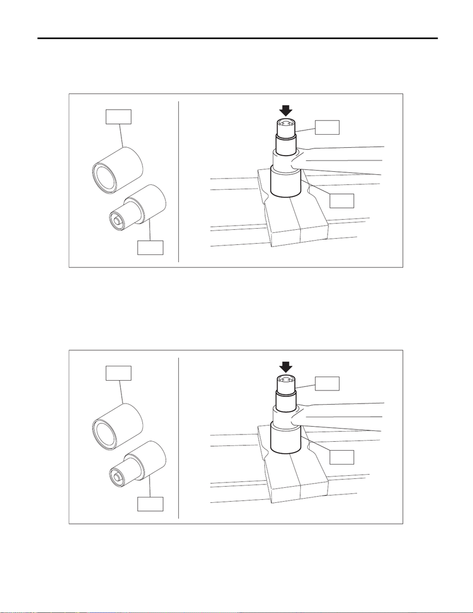

Rear Lateral Link

REAR SUSPENSION

C: DISASSEMBLY

Using the ST, push out the bushing.

Preparation tool:

ST-A & ST-B: INSTALLER & REMOVER (20099AE010)

D: ASSEMBLY

1) Before assembly, inspect the following items and replace any faulty part with a new one.

• Visually check the lateral link assembly - rear for damage and deformation.

• Visually check the bushing for abnormal cracks, fatigue or damage.

2) Using the ST, press the bushing into place.

Preparation tool:

ST-A & ST-B: INSTALLER & REMOVER (20099AE010)

RS-00350

ST-A

ST-B

ST-A

ST-B

RS-00350

ST-A

ST-B

ST-A

ST-B